# Gene Set Enrichment analysis part III: snRNAseq samples with metformin induced cardiac microtissue

Adapted from Gino Bonazza DCM samples analysis by Magdalena Czepiec and Maks Necki

**Magdalena Czepiec**  
Department of Clinical Immunology / Jagiellonian University  
[GitHub](https://github.com/czepiecmagdalena)

**Maks Necki**  
Department of Clinical Immunology / Jagiellonian University  
[GitHub](https://github.com/jungwirt)

# 1 Introduction

A module score represents a quantitative metric that summarizes the coordinated expression of a predefined gene set (e.g., genes associated with metabolism, stress response, or signaling pathways) into a single value for each cell or sample. It is computed by aggregating the expression levels of genes within a given biological category—often with normalization against control gene sets—thereby providing an integrated measure of pathway or process activity rather than relying on individual gene-level signals. This approach enables: - comparative assessment of pathway activity across cells, experimental conditions, or clusters, - identification of cellular subpopulations characterized by differential activation of specific biological processes, - reduction of data dimensionality, facilitating the interpretation of complex transcriptomic datasets.

## 1.1 Setup: Libraries and Environement

```r
  # ---- Package lists ----
  cran_packages <- c(
  "dplyr",
  "ggplot2",
  "patchwork",
  "htmltools",
  "tidyr",
  "Seurat",
  "stringr",
  "plotly",
  "kableExtra",
  "knitr",
  "sessioninfo"
  )

  bioc_packages <- c(
  "clusterProfiler",
  "org.Hs.eg.db",
  "enrichplot",
  "ReactomePA"
  )

  # ---- Function to install & load ----
  install_and_load <- function(pkg, bioc = FALSE) {
  if (!requireNamespace(pkg, quietly = TRUE)) {
    if (bioc) {
      if (!requireNamespace("BiocManager", quietly = TRUE)) {
        install.packages("BiocManager")
      }
      BiocManager::install(pkg, ask = FALSE, update = FALSE)
    } else {
      install.packages(pkg)
    }
  }
  library(pkg, character.only = TRUE)
  }

  # ---- Install & load CRAN packages ----
  invisible(lapply(cran_packages, install_and_load))

  # ---- Install & load Bioconductor packages ----
  invisible(lapply(bioc_packages, install_and_load, bioc = TRUE))

  cat("ALL PACKAGES SUCCESSFULLY LOADED")
```

```
## ALL PACKAGES SUCCESSFULLY LOADED
```

## 1.2 Helper function for importing extraction datasets without predefined gene lists (no genes after GSEA part II)

```r
  safe_read_csv <- function(path) {
  if (!file.exists(path)) {
    message("No file found (likely no genes / empty result): ", path)
    return(NULL)
  }

  df <- tryCatch(
    read.csv(path),
    error = function(e) NULL
  )

  if (is.null(df) || nrow(df) == 0) {
    message("File is empty or invalid: ", path)
    return(NULL)
  }

  return(df)
  }
```

## 1.3 Importing files after extraction (GSEA part II)

```r
# ---- Metabolism ----
score_mettgf_tgf_metabolism <- safe_read_csv("C:/Users/magda/Desktop/Lib_11_MTs_GSEA/Skrypty do publikacji/GSEA part II (Gene Extraction)/Cardiomyocytes/results_cardio_extraction_metabolism/mettgf_vs_tgf_Metabolism.csv")
score_tgf_nc_metabolism <- safe_read_csv("C:/Users/magda/Desktop/Lib_11_MTs_GSEA/Skrypty do publikacji/GSEA part II (Gene Extraction)/Cardiomyocytes/results_cardio_extraction_metabolism/tgf_vs_nc_Metabolism.csv")
score_met_nc_metabolism <- safe_read_csv("C:/Users/magda/Desktop/Lib_11_MTs_GSEA/Skrypty do publikacji/GSEA part II (Gene Extraction)/Cardiomyocytes/results_cardio_extraction_metabolism/met_vs_nc_Metabolism.csv")

# ---- Immune ----
score_mettgf_tgf_immune <- safe_read_csv("C:/Users/magda/Desktop/Lib_11_MTs_GSEA/Skrypty do publikacji/GSEA part II (Gene Extraction)/Cardiomyocytes/results_cardio_extraction_immune/mettgf_vs_tgf_Immune.csv")
score_tgf_nc_immune <- safe_read_csv("C:/Users/magda/Desktop/Lib_11_MTs_GSEA/Skrypty do publikacji/GSEA part II (Gene Extraction)/Cardiomyocytes/results_cardio_extraction_immune/tgf_vs_nc_Immune.csv")
```

```
## No file found (likely no genes / empty result): C:/Users/magda/Desktop/Lib_11_MTs_GSEA/Skrypty do publikacji/GSEA part II (Gene Extraction)/Cardiomyocytes/results_cardio_extraction_immune/tgf_vs_nc_Immune.csv
```

```r
score_met_nc_immune <- safe_read_csv("C:/Users/magda/Desktop/Lib_11_MTs_GSEA/Skrypty do publikacji/GSEA part II (Gene Extraction)/Cardiomyocytes/results_cardio_extraction_immune/met_vs_nc_Immune.csv")
```

```
## No file found (likely no genes / empty result): C:/Users/magda/Desktop/Lib_11_MTs_GSEA/Skrypty do publikacji/GSEA part II (Gene Extraction)/Cardiomyocytes/results_cardio_extraction_immune/met_vs_nc_Immune.csv
```

```r
# ---- Migration ----
score_mettgf_tgf_migration <- safe_read_csv("C:/Users/magda/Desktop/Lib_11_MTs_GSEA/Skrypty do publikacji/GSEA part II (Gene Extraction)/Cardiomyocytes/results_cardio_extraction_migration/mettgf_vs_tgf_Migration.csv")
score_tgf_nc_migration <- safe_read_csv("C:/Users/magda/Desktop/Lib_11_MTs_GSEA/Skrypty do publikacji/GSEA part II (Gene Extraction)/Cardiomyocytes/results_cardio_extraction_migration/tgf_vs_nc_Migration.csv")
score_met_nc_migration <- safe_read_csv("C:/Users/magda/Desktop/Lib_11_MTs_GSEA/Skrypty do publikacji/GSEA part II (Gene Extraction)/Cardiomyocytes/results_cardio_extraction_migration/met_vs_nc_Migration.csv")

# ---- Cell cycle ----
score_mettgf_tgf_cellcycle <- safe_read_csv("C:/Users/magda/Desktop/Lib_11_MTs_GSEA/Skrypty do publikacji/GSEA part II (Gene Extraction)/Cardiomyocytes/results_cardio_extraction_cellcycle/mettgf_vs_tgf_Cell_cycle.csv")
```

```
## No file found (likely no genes / empty result): C:/Users/magda/Desktop/Lib_11_MTs_GSEA/Skrypty do publikacji/GSEA part II (Gene Extraction)/Cardiomyocytes/results_cardio_extraction_cellcycle/mettgf_vs_tgf_Cell_cycle.csv
```

```r
score_tgf_nc_cellcycle <- safe_read_csv("C:/Users/magda/Desktop/Lib_11_MTs_GSEA/Skrypty do publikacji/GSEA part II (Gene Extraction)/Cardiomyocytes/results_cardio_extraction_cellcycle/tgf_vs_nc_Cell_cycle.csv")
```

```
## No file found (likely no genes / empty result): C:/Users/magda/Desktop/Lib_11_MTs_GSEA/Skrypty do publikacji/GSEA part II (Gene Extraction)/Cardiomyocytes/results_cardio_extraction_cellcycle/tgf_vs_nc_Cell_cycle.csv
```

```r
score_met_nc_cellcycle <- safe_read_csv("C:/Users/magda/Desktop/Lib_11_MTs_GSEA/Skrypty do publikacji/GSEA part II (Gene Extraction)/Cardiomyocytes/results_cardio_extraction_cellcycle/met_vs_nc_Cell_cycle.csv")

# ---- Signaling ----
score_mettgf_tgf_signaling <- safe_read_csv("C:/Users/magda/Desktop/Lib_11_MTs_GSEA/Skrypty do publikacji/GSEA part II (Gene Extraction)/Cardiomyocytes/results_cardio_extraction_signaling/mettgf_vs_tgf_Signaling.csv")
score_tgf_nc_signaling <- safe_read_csv("C:/Users/magda/Desktop/Lib_11_MTs_GSEA/Skrypty do publikacji/GSEA part II (Gene Extraction)/Cardiomyocytes/results_cardio_extraction_signaling/tgf_vs_nc_Signaling.csv")
score_met_nc_signaling <- safe_read_csv("C:/Users/magda/Desktop/Lib_11_MTs_GSEA/Skrypty do publikacji/GSEA part II (Gene Extraction)/Cardiomyocytes/results_cardio_extraction_signaling/met_vs_nc_Signaling.csv")

# ---- Development ----
score_mettgf_tgf_development <- safe_read_csv("C:/Users/magda/Desktop/Lib_11_MTs_GSEA/Skrypty do publikacji/GSEA part II (Gene Extraction)/Cardiomyocytes/results_cardio_extraction_development/mettgf_vs_tgf_Development.csv")
score_tgf_nc_development <- safe_read_csv("C:/Users/magda/Desktop/Lib_11_MTs_GSEA/Skrypty do publikacji/GSEA part II (Gene Extraction)/Cardiomyocytes/results_cardio_extraction_development/tgf_vs_nc_Development.csv")
score_met_nc_development <- safe_read_csv("C:/Users/magda/Desktop/Lib_11_MTs_GSEA/Skrypty do publikacji/GSEA part II (Gene Extraction)/Cardiomyocytes/results_cardio_extraction_development/met_vs_nc_Development.csv")

# ---- Cell death ----
score_mettgf_tgf_celldeath <- safe_read_csv("C:/Users/magda/Desktop/Lib_11_MTs_GSEA/Skrypty do publikacji/GSEA part II (Gene Extraction)/Cardiomyocytes/results_cardio_extraction_celldeath/mettgf_vs_tgf_Cell_death.csv")
```

```
## No file found (likely no genes / empty result): C:/Users/magda/Desktop/Lib_11_MTs_GSEA/Skrypty do publikacji/GSEA part II (Gene Extraction)/Cardiomyocytes/results_cardio_extraction_celldeath/mettgf_vs_tgf_Cell_death.csv
```

```r
score_tgf_nc_celldeath <- safe_read_csv("C:/Users/magda/Desktop/Lib_11_MTs_GSEA/Skrypty do publikacji/GSEA part II (Gene Extraction)/Cardiomyocytes/results_cardio_extraction_celldeath/tgf_vs_nc_Cell_death.csv")
```

```
## No file found (likely no genes / empty result): C:/Users/magda/Desktop/Lib_11_MTs_GSEA/Skrypty do publikacji/GSEA part II (Gene Extraction)/Cardiomyocytes/results_cardio_extraction_celldeath/tgf_vs_nc_Cell_death.csv
```

```r
score_met_nc_celldeath <- safe_read_csv("C:/Users/magda/Desktop/Lib_11_MTs_GSEA/Skrypty do publikacji/GSEA part II (Gene Extraction)/Cardiomyocytes/results_cardio_extraction_celldeath/met_vs_nc_Cell_death.csv")
```

## 1.4 Importing Seurat object containing analyzed and processed cardioblast cells from all conditions

```r
Cardio <- readRDS("C:/Users/magda/Desktop/Lib_11_MTs_GSEA/Skrypty do publikacji/GSEA part III (Category Score)/Cardio.rds")
```

# 2 Computing module scores for each biological category

```r
  # ---- Genes within metabolic category ----
  genes_tgf_nc_metabolism <- unique(as.character(score_tgf_nc_metabolism$x))
  genes_mettgf_tgf_metabolism <- unique(as.character(score_mettgf_tgf_metabolism$x))
  genes_met_nc_metabolism <- unique(as.character(score_met_nc_metabolism$x))

  genes_all_metabolism <- unique(c(
  genes_met_nc_metabolism,
  genes_mettgf_tgf_metabolism,
  genes_tgf_nc_metabolism
  ))

  genes_intersect_list_metabolism <- intersect(genes_all_metabolism, rownames(Cardio))

  if (length(genes_intersect_list_metabolism) < 5) {
  message("Too few genes for module score: ", length(genes_intersect_list_metabolism))

  Cardio$Metabolism_Score_all1 <- NA

  } else {

  Cardio <- AddModuleScore(
    Cardio,
    features = list(genes_intersect_list_metabolism),
    name = "Metabolism_Score_all"
  )
  }

# ---- Genes within immune category ----
  genes_tgf_nc_immune <- unique(as.character(score_tgf_nc_immune$x))
  genes_mettgf_tgf_immune <- unique(as.character(score_mettgf_tgf_immune$x))
  genes_met_nc_immune <- unique(as.character(score_met_nc_immune$x))

  genes_all_immune <- unique(c(
  genes_met_nc_immune,
  genes_mettgf_tgf_immune,
  genes_tgf_nc_immune
  ))

  genes_intersect_list_immune <- intersect(genes_all_immune, rownames(Cardio))

  if (length(genes_intersect_list_immune) < 5) {
  message("Too few genes for module score: ", length(genes_intersect_list_immune))

  Cardio$Immune_Score_all1 <- NA

  } else {

  Cardio <- AddModuleScore(
    Cardio,
    features = list(genes_intersect_list_immune),
    name = "Immune_Score_all"
  )
  }
```

```
## Too few genes for module score: 4
```

```r
  # ---- Genes within migration category ----
  genes_tgf_nc_migration <- unique(as.character(score_tgf_nc_migration$x))
  genes_mettgf_tgf_migration <- unique(as.character(score_mettgf_tgf_migration$x))
  genes_met_nc_migration <- unique(as.character(score_met_nc_migration$x))

  genes_all_migration <- unique(c(
  genes_met_nc_migration,
  genes_mettgf_tgf_migration,
  genes_tgf_nc_migration
  ))

  genes_intersect_list_migration <- intersect(genes_all_migration, rownames(Cardio))

  if (length(genes_intersect_list_migration) < 5) {
  message("Too few genes for module score: ", length(genes_intersect_list_migration))

  Cardio$Migration_Score_all1 <- NA

  } else {

  Cardio <- AddModuleScore(
    Cardio,
    features = list(genes_intersect_list_migration),
    name = "Migration_Score_all"
  )
  }

  # ---- Genes within cell cycle category ----
  genes_tgf_nc_cellcycle <- unique(as.character(score_tgf_nc_cellcycle$x))
  genes_mettgf_tgf_cellcycle <- unique(as.character(score_mettgf_tgf_cellcycle$x))
  genes_met_nc_cellcycle <- unique(as.character(score_met_nc_cellcycle$x))

  genes_all_cellcycle <- unique(c(
  genes_met_nc_cellcycle,
  genes_mettgf_tgf_cellcycle,
  genes_tgf_nc_cellcycle
  ))

  genes_intersect_list_cellcycle <- intersect(genes_all_cellcycle, rownames(Cardio))

  if (length(genes_intersect_list_cellcycle) < 5) {
  message("Too few genes for module score: ", length(genes_intersect_list_cellcycle))

  Cardio$Cell_cycle_Score_all1 <- NA

  } else {

  Cardio <- AddModuleScore(
    Cardio,
    features = list(genes_intersect_list_cellcycle),
    name = "Cell_cycle_Score_all"
  )
  }
```

```
## Too few genes for module score: 1
```

```r
  # ---- Genes within signaling category ----
  genes_tgf_nc_signaling <- unique(as.character(score_tgf_nc_signaling$x))
  genes_mettgf_tgf_signaling <- unique(as.character(score_mettgf_tgf_signaling$x))
  genes_met_nc_signaling <- unique(as.character(score_met_nc_signaling$x))

  genes_all_signaling <- unique(c(
  genes_met_nc_signaling,
  genes_mettgf_tgf_signaling,
  genes_tgf_nc_signaling
  ))

  genes_intersect_list_signaling <- intersect(genes_all_signaling, rownames(Cardio))

  if (length(genes_intersect_list_signaling) < 5) {
  message("Too few genes for module score: ", length(genes_intersect_list_signaling))

  Cardio$Signaling_Score_all1 <- NA

  } else {

  Cardio <- AddModuleScore(
    Cardio,
    features = list(genes_intersect_list_signaling),
    name = "Signaling_Score_all"
  )
  }

  # ---- Genes within development category ----
  genes_tgf_nc_development <- unique(as.character(score_tgf_nc_development$x))
  genes_mettgf_tgf_development <- unique(as.character(score_mettgf_tgf_development$x))
  genes_met_nc_development <- unique(as.character(score_met_nc_development$x))

  genes_all_development <- unique(c(
  genes_met_nc_development,
  genes_mettgf_tgf_development,
  genes_tgf_nc_development
  ))

  genes_intersect_list_development <- intersect(genes_all_development, rownames(Cardio))

  if (length(genes_intersect_list_development) < 5) {
  message("Too few genes for module score: ", length(genes_intersect_list_development))

  Cardio$Development_Score_all1 <- NA

  } else {

  Cardio <- AddModuleScore(
    Cardio,
    features = list(genes_intersect_list_development),
    name = "Development_Score_all"
  )
  }

  # ---- Genes within cell death category ----
  genes_tgf_nc_celldeath <- unique(as.character(score_tgf_nc_celldeath$x))
  genes_mettgf_tgf_celldeath <- unique(as.character(score_mettgf_tgf_celldeath$x))
  genes_met_nc_celldeath <- unique(as.character(score_met_nc_celldeath$x))

  genes_all_celldeath <- unique(c(
  genes_met_nc_celldeath,
  genes_mettgf_tgf_celldeath,
  genes_tgf_nc_celldeath
  ))

  genes_intersect_list_celldeath <- intersect(genes_all_celldeath, rownames(Cardio))

  if (length(genes_intersect_list_celldeath) < 5) {
  message("Too few genes for module score: ", length(genes_intersect_list_celldeath))

  Cardio$Cell_death_Score_all1 <- NA

  } else {

  Cardio <- AddModuleScore(
    Cardio,
    features = list(genes_intersect_list_celldeath),
    name = "Cell_death_Score_all"
  )
  }
```

```
## Too few genes for module score: 1
```

## 2.1 Visualizing Metabolic Scores

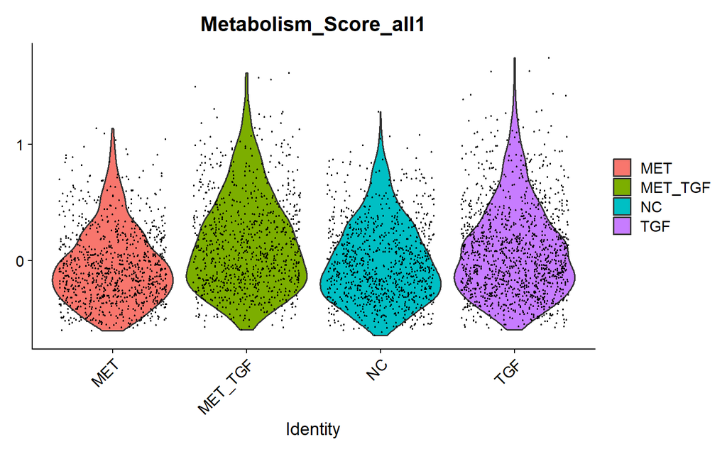

```r
VlnPlot(Cardio, features = "Metabolism_Score_all1", group.by = "condition")
```

```r
p <- VlnPlot(Cardio, features = "Metabolism_Score_all1", group.by = "condition")
ggsave(
  filename = "Metabolism_Score_all1.jpg",
  plot = p,
  width = 8,
  height = 6,
  dpi = 300
)
```

## 2.2 Visualizing Migration Scores

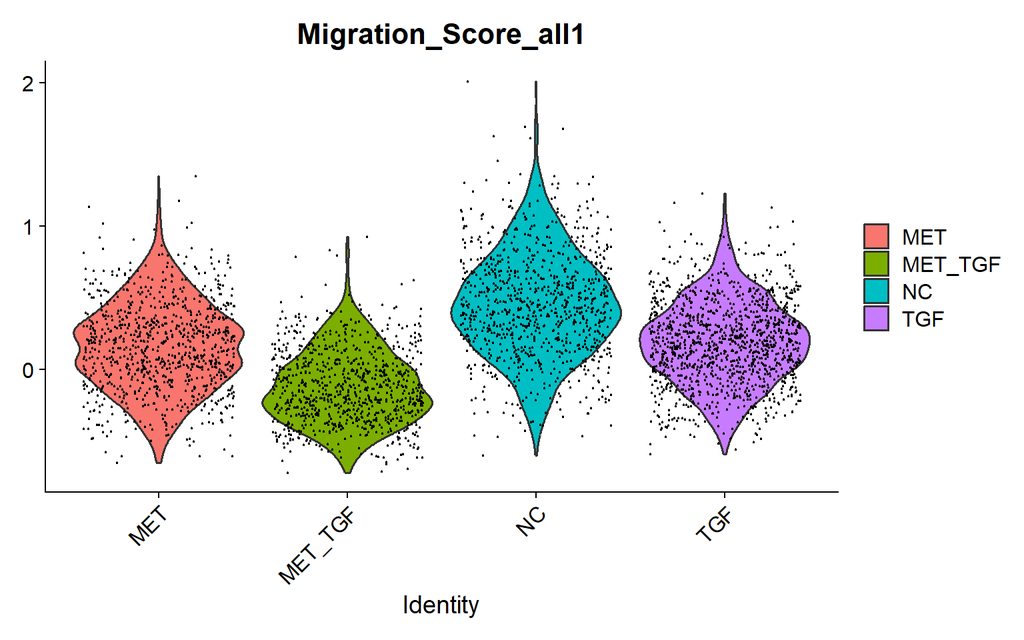

```r
VlnPlot(Cardio, features = "Migration_Score_all1", group.by = "condition")
```

```r
p <- VlnPlot(Cardio, features = "Migration_Score_all1", group.by = "condition")
ggsave(
  filename = "Migration_Score_all1.jpg",
  plot = p,
  width = 8,
  height = 6,
  dpi = 300
)
```

## 2.3 Visualizing Immune Scores

```r
if ("Immune_Score_all1" %in% colnames(Cardio@meta.data) &&
    !all(is.na(Cardio$Immune_Score_all1))) {

  p1 <- VlnPlot(
    Cardio,
    features = "Immune_Score_all1",
    group.by = "condition"
  )

} else {

  p1 <- ggplot() +
    annotate(
      "text",
      x = 0.5, y = 0.5,
      label = "Genes set to small to generate module score (lower than 5)",
      size = 6
    ) +
    theme_void()
}
p1
```

```r
ggsave(
  filename = "Immune_Score_all1.jpg",
  plot = p1,
  width = 8,
  height = 6,
  dpi = 300
)
```

## 2.4 Visualizing Cell Cycle Scores

```r
if ("Cell_cycle_Score_all1" %in% colnames(Cardio@meta.data) &&
    !all(is.na(Cardio$Cell_cycle_Score_all1))) {

  p1 <- VlnPlot(
    Cardio,
    features = "Cell_cycle_Score_all1",
    group.by = "condition"
  )

} else {

  p1 <- ggplot() +
    annotate(
      "text",
      x = 0.5, y = 0.5,
      label = "Genes set to small to generate module score (lower than 5)",
      size = 6
    ) +
    theme_void()
}
p1
```

```r
ggsave(
  filename = "Cell_cycle_Score_all1.jpg",
  plot = p1,
  width = 8,
  height = 6,
  dpi = 300
)
```

## 2.5 Visualizing Signaling Scores

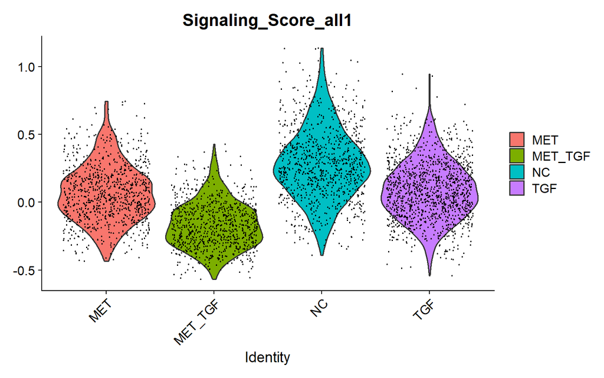

```r
VlnPlot(Cardio, features = "Signaling_Score_all1", group.by = "condition")
```

```r
p <- VlnPlot(Cardio, features = "Signaling_Score_all1", group.by = "condition")
ggsave(
  filename = "Signaling_Score_all1.jpg",
  plot = p,
  width = 8,
  height = 6,
  dpi = 300
)
```

## 2.6 Visualizing Development Scores

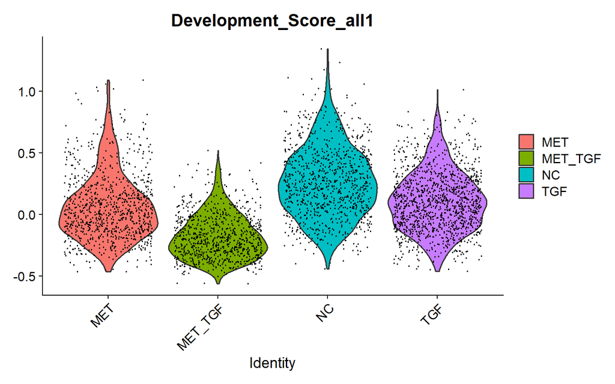

```r
VlnPlot(Cardio, features = "Development_Score_all1", group.by = "condition")
```

```r
p <- VlnPlot(Cardio, features = "Development_Score_all1", group.by = "condition")
ggsave(
  filename = "Development_Score_all1.jpg",
  plot = p,
  width = 8,
  height = 6,
  dpi = 300
)
```

## 2.7 Visualizing Cell Death Scores

```r
if ("Cell_death_Score_all1" %in% colnames(Cardio@meta.data) &&
    !all(is.na(Cardio$Cell_death_Score_all1))) {

  p1 <- VlnPlot(
    Cardio,
    features = "Cell_death_Score_all1",
    group.by = "condition"
  )

} else {

  p1 <- ggplot() +
    annotate(
      "text",
      x = 0.5, y = 0.5,
      label = "Genes set to small to generate module score (lower than 5)",
      size = 6
    ) +
    theme_void()
}
p1
```

```r
ggsave(
  filename = "Cell_death_Score_all1.jpg",
  plot = p1,
  width = 8,
  height = 6,
  dpi = 300
)
```

# 3 Computing module scores for each biological category only for MET_TGF vs TGF comparison

```r
  # ---- Genes within metabolic category ----
  genes_mettgf_tgf_metabolism <- unique(as.character(score_mettgf_tgf_metabolism$x))

  genes_intersect_list_metabolism_mettgf_tgf <- intersect(genes_mettgf_tgf_metabolism, rownames(Cardio))

  if (length(genes_intersect_list_metabolism_mettgf_tgf) < 5) {
  message("Too few genes for module score: ", length(genes_intersect_list_metabolism_mettgf_tgf))

  Cardio$Metabolism_Score_mettgf_tgf1 <- NA

  } else {

  Cardio <- AddModuleScore(
    Cardio,
    features = list(genes_intersect_list_metabolism_mettgf_tgf),
    name = "Metabolism_Score_mettgf_tgf"
  )
  }
```

```
## Too few genes for module score: 4
```

```r
# ---- Genes within immune category ----
  genes_mettgf_tgf_immune <- unique(as.character(score_mettgf_tgf_immune$x))

  genes_intersect_list_immune_mettgf_tgf <- intersect(genes_mettgf_tgf_immune, rownames(Cardio))

  if (length(genes_intersect_list_immune_mettgf_tgf) < 5) {
  message("Too few genes for module score: ", length(genes_intersect_list_immune_mettgf_tgf))

  Cardio$Immune_Score_mettgf_tgf1 <- NA

  } else {

  Cardio <- AddModuleScore(
    Cardio,
    features = list(genes_intersect_list_immune_mettgf_tgf),
    name = "Immune_Score_mettgf_tgf"
  )
  }
```

```
## Too few genes for module score: 4
```

```r
  # ---- Genes within migration category ----
  genes_mettgf_tgf_migration <- unique(as.character(score_mettgf_tgf_migration$x))

  genes_intersect_list_migration_mettgf_tgf <- intersect(genes_mettgf_tgf_migration, rownames(Cardio))

  if (length(genes_intersect_list_migration_mettgf_tgf) < 5) {
  message("Too few genes for module score: ", length(genes_intersect_list_migration_mettgf_tgf))

  Cardio$Migration_Score_mettgf_tgf1 <- NA

  } else {

  Cardio <- AddModuleScore(
    Cardio,
    features = list(genes_intersect_list_migration_mettgf_tgf),
    name = "Migration_Score_mettgf_tgf"
  )
  }

  # ---- Genes within cell cycle category ----
  genes_mettgf_tgf_cellcycle <- unique(as.character(score_mettgf_tgf_cellcycle$x))

  genes_intersect_list_cellcycle_mettgf_tgf <- intersect(genes_mettgf_tgf_cellcycle, rownames(Cardio))

  if (length(genes_intersect_list_cellcycle_mettgf_tgf) < 5) {
  message("Too few genes for module score: ", length(genes_intersect_list_cellcycle_mettgf_tgf))

  Cardio$Cell_cycle_Score_mettgf_tgf1 <- NA

  } else {

  Cardio <- AddModuleScore(
    Cardio,
    features = list(genes_intersect_list_cellcycle_mettgf_tgf),
    name = "Cell_cycle_Score_mettgf_tgf"
  )
  }
```

```
## Too few genes for module score: 0
```

```r
  # ---- Genes within signaling category ----
  genes_mettgf_tgf_signaling <- unique(as.character(score_mettgf_tgf_signaling$x))

  genes_intersect_list_signaling_mettgf_tgf <- intersect(genes_mettgf_tgf_signaling, rownames(Cardio))

  if (length(genes_intersect_list_signaling_mettgf_tgf) < 5) {
  message("Too few genes for module score: ", length(genes_intersect_list_signaling_mettgf_tgf))

  Cardio$Signaling_Score_mettgf_tgf1 <- NA

  } else {

  Cardio <- AddModuleScore(
    Cardio,
    features = list(genes_intersect_list_signaling_mettgf_tgf),
    name = "Signaling_Score_mettgf_tgf"
  )
  }

  # ---- Genes within development category ----
  genes_mettgf_tgf_development <- unique(as.character(score_mettgf_tgf_development$x))

  genes_intersect_list_development_mettgf_tgf <- intersect(genes_mettgf_tgf_development, rownames(Cardio))

  if (length(genes_intersect_list_development_mettgf_tgf) < 5) {
  message("Too few genes for module score: ", length(genes_intersect_list_development_mettgf_tgf))

  Cardio$Development_Score_mettgf_tgf1 <- NA

  } else {

  Cardio <- AddModuleScore(
    Cardio,
    features = list(genes_intersect_list_development_mettgf_tgf),
    name = "Development_Score_mettgf_tgf"
  )
  }

  # ---- Genes within cell death category ----
  genes_mettgf_tgf_celldeath <- unique(as.character(score_mettgf_tgf_celldeath$x))

  genes_intersect_list_celldeath_mettgf_tgf <- intersect(genes_mettgf_tgf_celldeath, rownames(Cardio))

  if (length(genes_intersect_list_celldeath_mettgf_tgf) < 5) {
  message("Too few genes for module score: ", length(genes_intersect_list_celldeath_mettgf_tgf))

  Cardio$Cell_death_Score_mettgf_tgf1 <- NA

  } else {

  Cardio <- AddModuleScore(
    Cardio,
    features = list(genes_intersect_list_celldeath_mettgf_tgf),
    name = "Cell_death_Score_mettgf_tgf"
  )
  }
```

```
## Too few genes for module score: 0
```

## 3.1 Visualizing Metabolic Scores for mettgf_tgf comparision only

```r
if ("Metabolism_Score_mettgf_tgf1" %in% colnames(Cardio@meta.data) &&
    !all(is.na(Cardio$Metabolism_Score_mettgf_tgf1))) {

  p1 <- VlnPlot(
    Cardio,
    features = "Metabolism_Score_mettgf_tgf1",
    group.by = "condition"
  )

} else {

  p1 <- ggplot() +
    annotate(
      "text",
      x = 0.5, y = 0.5,
      label = "Genes set to small to generate module score (lower than 5)",
      size = 6
    ) +
    theme_void()
}
p1
```

```r
ggsave(
  filename = "Metabolism_Score_mettgf_tgf1.jpg",
  plot = p1,
  width = 8,
  height = 6,
  dpi = 300
)
```

## 3.2 Visualizing Migration Scores for mettgf_tgf comparision only

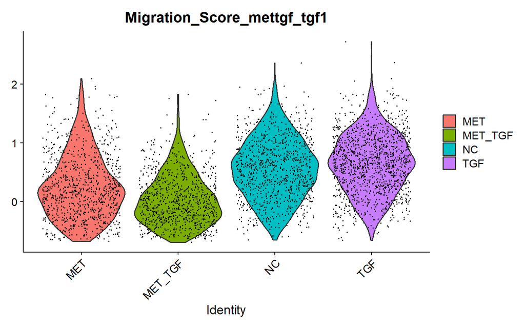

```r
VlnPlot(Cardio, features = "Migration_Score_mettgf_tgf1", group.by = "condition")
```

```r
p1 <- VlnPlot(Cardio, features = "Migration_Score_mettgf_tgf1", group.by = "condition")
ggsave(
  filename = "Migration_Score_mettgf_tgf1.jpg",
  plot = p1,
  width = 8,
  height = 6,
  dpi = 300
)
```

## 3.3 Visualizing Immune Scores for mettgf_tgf comparision only

```r
if ("Immune_Score_mettgf_tgf1" %in% colnames(Cardio@meta.data) &&
    !all(is.na(Cardio$Immune_Score_mettgf_tgf1))) {

  p1 <- VlnPlot(
    Cardio,
    features = "Immune_Score_mettgf_tgf1",
    group.by = "condition"
  )

} else {

  p1 <- ggplot() +
    annotate(
      "text",
      x = 0.5, y = 0.5,
      label = "Genes set to small to generate module score (lower than 5)",
      size = 6
    ) +
    theme_void()
}
p1
```

```r
ggsave(
  filename = "Immune_Score_mettgf_tgf1.jpg",
  plot = p1,
  width = 8,
  height = 6,
  dpi = 300
)
```

## 3.4 Visualizing Cell Cycle Scores for mettgf_tgf comparision only

```r
if ("Cell_cycle_Score_mettgf_tgf1" %in% colnames(Cardio@meta.data) &&
    !all(is.na(Cardio$Cell_cycle_Score_mettgf_tgf1))) {

  p1 <- VlnPlot(
    Cardio,
    features = "Cell_cycle_Score_mettgf_tgf1",
    group.by = "condition"
  )

} else {

  p1 <- ggplot() +
    annotate(
      "text",
      x = 0.5, y = 0.5,
      label = "Genes set to small to generate module score (lower than 5)",
      size = 6
    ) +
    theme_void()
}
p1
```

```r
ggsave(
  filename = "Cell_cycle_Score_mettgf_tgf1.jpg",
  plot = p1,
  width = 8,
  height = 6,
  dpi = 300
)
```

## 3.5 Visualizing Signaling Scores for mettgf_tgf comparision only

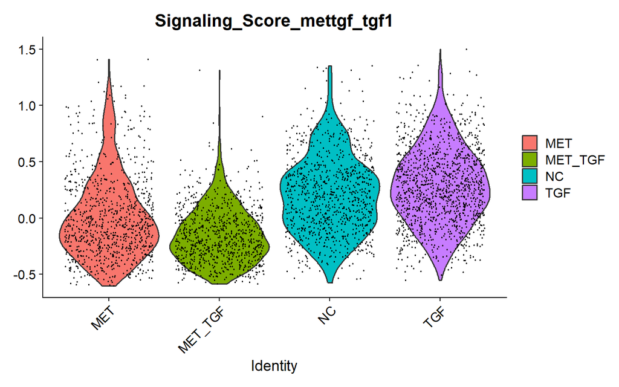

```r
VlnPlot(Cardio, features = "Signaling_Score_mettgf_tgf1", group.by = "condition")
```

```r
p1 <- VlnPlot(Cardio, features = "Signaling_Score_mettgf_tgf1", group.by = "condition")
ggsave(
  filename = "Signaling_Score_mettgf_tgf1.jpg",
  plot = p1,
  width = 8,
  height = 6,
  dpi = 300
)
```

## 3.6 Visualizing Development Scores for mettgf_tgf comparision only

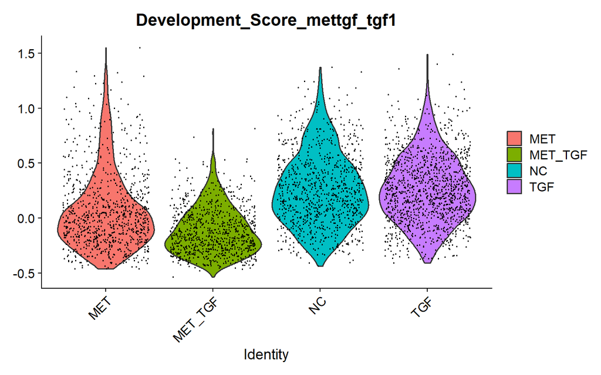

```r
VlnPlot(Cardio, features = "Development_Score_mettgf_tgf1", group.by = "condition")
```

```r
p1 <- VlnPlot(Cardio, features = "Development_Score_mettgf_tgf1", group.by = "condition")
ggsave(
  filename = "Development_Score_mettgf_tgf1.jpg",
  plot = p1,
  width = 8,
  height = 6,
  dpi = 300
)
```

## 3.7 Visualizing Cell Death Scores for mettgf_tgf comparision only

```r
if ("Cell_death_Score_mettgf_tgf1" %in% colnames(Cardio@meta.data) &&
    !all(is.na(Cardio$Cell_death_Score_mettgf_tgf1))) {

  p1 <- VlnPlot(
    Cardio,
    features = "Cell_death_Score_mettgf_tgf1",
    group.by = "condition"
  )

} else {

  p1 <- ggplot() +
    annotate(
      "text",
      x = 0.5, y = 0.5,
      label = "Genes set to small to generate module score (lower than 5)",
      size = 6
    ) +
    theme_void()
}
p1
```

```r
ggsave(
  filename = "Cell_death_Score_mettgf_tgf1.jpg",
  plot = p1,
  width = 8,
  height = 6,
  dpi = 300
)
```

# 4 Computing module scores: compare all vs MET_TGF vs TGF comparison only

## 4.1 Visualizing Metabolic Scores compare all vs mettgf_tgf

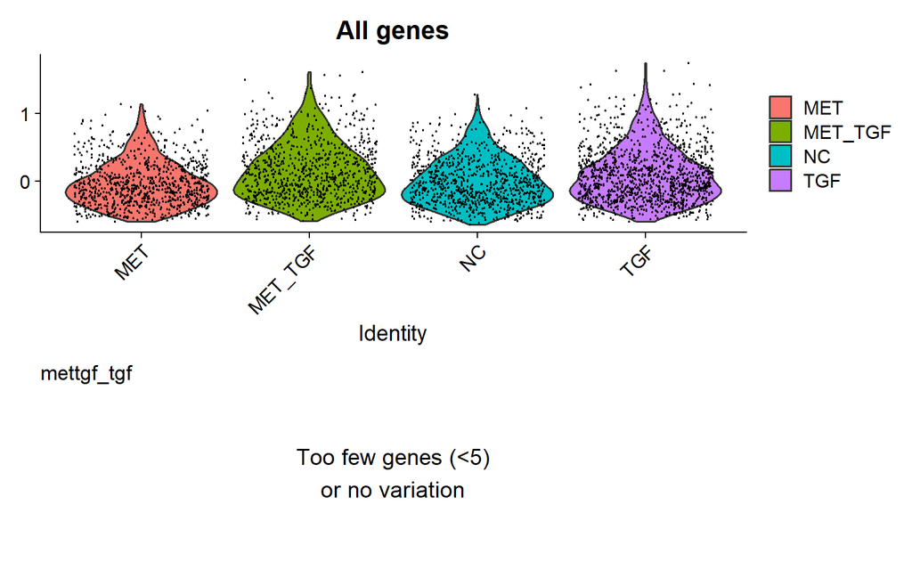

```r
# --- plot 1 ---
if ("Metabolism_Score_all1" %in% colnames(Cardio@meta.data) &&
    !all(is.na(Cardio$Metabolism_Score_all1)) &&
    length(unique(na.omit(Cardio$Metabolism_Score_all1))) > 1) {

  p_all <- VlnPlot(
    Cardio,
    features = "Metabolism_Score_all1",
    group.by = "condition"
  ) + ggtitle("All genes")

} else {

  p_all <- ggplot() +
    annotate("text", x = 0.5, y = 0.5,
             label = "No valid data (NA or no variation)",
             size = 5) +
    theme_void() +
    ggtitle("All genes")
}

# --- plot 2 ---
if ("Metabolism_Score_mettgf_tgf1" %in% colnames(Cardio@meta.data) &&
    !all(is.na(Cardio$Metabolism_Score_mettgf_tgf1)) &&
    length(unique(na.omit(Cardio$Metabolism_Score_mettgf_tgf1))) > 1) {

  p_cond <- VlnPlot(
    Cardio,
    features = "Metabolism_Score_mettgf_tgf1",
    group.by = "condition"
  ) + ggtitle("mettgf_tgf")

} else {

  p_cond <- ggplot() +
    annotate(
      "text",
      x = 0.5, y = 0.5,
      label = "Too few genes (<5)\nor no variation",
      size = 5
    ) +
    theme_void() +
    ggtitle("mettgf_tgf")
}

# --- Combined ---
p_combined <- p_all + p_cond
p_combined
```

```r
ggsave(
  filename = "Metabolism_Score_combine1.jpg",
  plot = p_combined,
  width = 12,
  height = 6,
  dpi = 300
)
```

## 4.2 Visualizing Migration Scores compare all vs mettgf_tgf

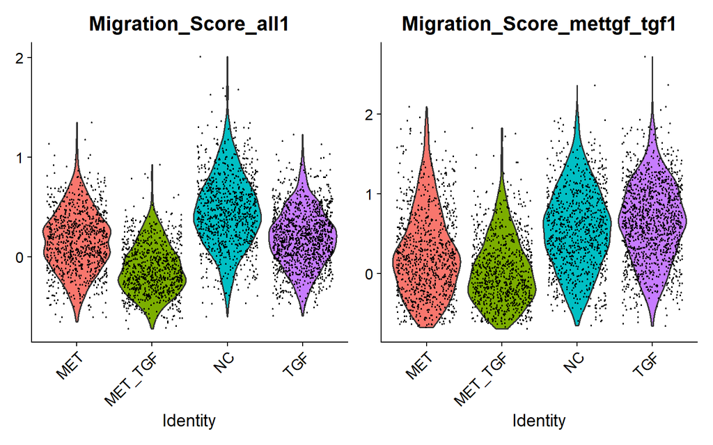

```r
p <- VlnPlot(
  Cardio,
  features = c("Migration_Score_all1", "Migration_Score_mettgf_tgf1"),
  group.by = "condition",
  combine = TRUE
)
p
```

```r
ggsave(
  filename = "Migration_Score_combine1.jpg",
  plot = p,
  width = 8,
  height = 6,
  dpi = 300
)
```

## 4.3 Visualizing Immune Scores compare all vs mettgf_tgf

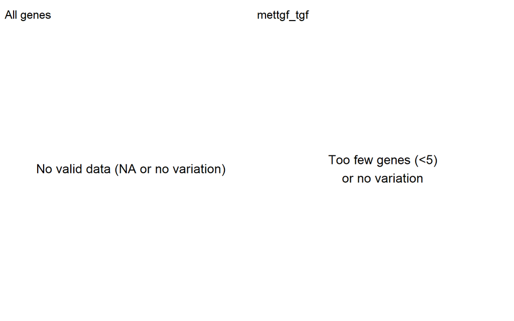

```r
# --- plot 1 ---
if ("Immune_Score_all1" %in% colnames(Cardio@meta.data) &&
    !all(is.na(Cardio$Immune_Score_all1)) &&
    length(unique(na.omit(Cardio$Immune_Score_all1))) > 1) {

  p_all <- VlnPlot(
    Cardio,
    features = "Immune_Score_all1",
    group.by = "condition"
  ) + ggtitle("All genes")

} else {

  p_all <- ggplot() +
    annotate("text", x = 0.5, y = 0.5,
             label = "No valid data (NA or no variation)",
             size = 5) +
    theme_void() +
    ggtitle("All genes")
}

# --- plot 2 ---
if ("Immune_Score_mettgf_tgf1" %in% colnames(Cardio@meta.data) &&
    !all(is.na(Cardio$Immune_Score_mettgf_tgf1)) &&
    length(unique(na.omit(Cardio$Immune_Score_mettgf_tgf1))) > 1) {

  p_cond <- VlnPlot(
    Cardio,
    features = "Immune_Score_mettgf_tgf1",
    group.by = "condition"
  ) + ggtitle("mettgf_tgf")

} else {

  p_cond <- ggplot() +
    annotate(
      "text",
      x = 0.5, y = 0.5,
      label = "Too few genes (<5)\nor no variation",
      size = 5
    ) +
    theme_void() +
    ggtitle("mettgf_tgf")
}

# --- Combined ---
p_combined <- p_all + p_cond
p_combined
```

```r
ggsave(
  filename = "Immune_Score_combine1.jpg",
  plot = p_combined,
  width = 12,
  height = 6,
  dpi = 300
)
```

## 4.4 Visualizing Cell Cycle Scores compare all vs mettgf_tgf

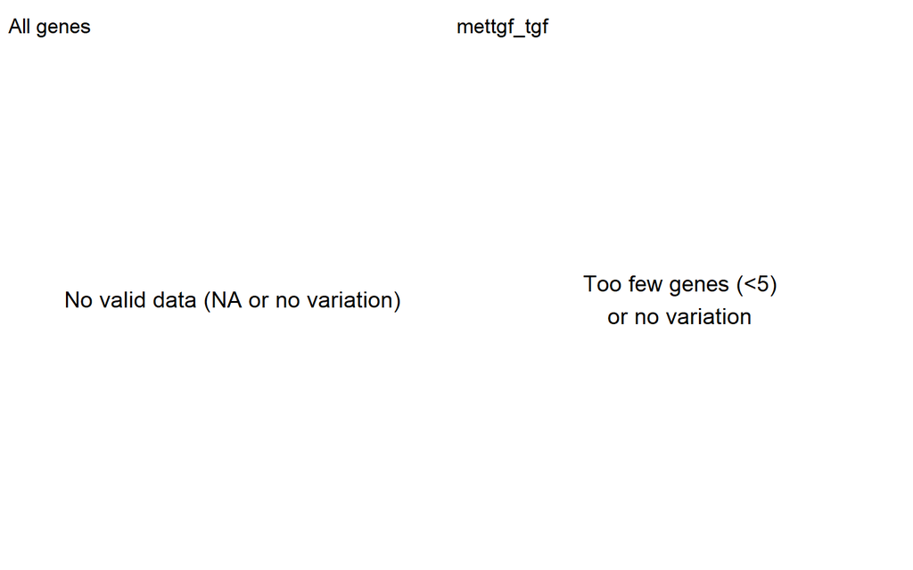

```r
# --- plot 1 ---
if ("Cell_cycle_Score_all1" %in% colnames(Cardio@meta.data) &&
    !all(is.na(Cardio$Cell_cycle_Score_all1)) &&
    length(unique(na.omit(Cardio$Cell_cycle_Score_all1))) > 1) {

  p_all <- VlnPlot(
    Cardio,
    features = "Cell_cycle_Score_all1",
    group.by = "condition"
  ) + ggtitle("All genes")

} else {

  p_all <- ggplot() +
    annotate("text", x = 0.5, y = 0.5,
             label = "No valid data (NA or no variation)",
             size = 5) +
    theme_void() +
    ggtitle("All genes")
}

# --- plot 2 ---
if ("Cell_cycle_Score_mettgf_tgf1" %in% colnames(Cardio@meta.data) &&
    !all(is.na(Cardio$Cell_cycle_Score_mettgf_tgf1)) &&
    length(unique(na.omit(Cardio$Cell_cycle_Score_mettgf_tgf1))) > 1) {

  p_cond <- VlnPlot(
    Cardio,
    features = "Cell_cycle_Score_mettgf_tgf1",
    group.by = "condition"
  ) + ggtitle("mettgf_tgf")

} else {

  p_cond <- ggplot() +
    annotate(
      "text",
      x = 0.5, y = 0.5,
      label = "Too few genes (<5)\nor no variation",
      size = 5
    ) +
    theme_void() +
    ggtitle("mettgf_tgf")
}

# --- Combined ---
library(patchwork)
p_combined <- p_all + p_cond
p_combined
```

```r
ggsave(
  filename = "Cell_cycle_Score_combine1.jpg",
  plot = p_combined,
  width = 12,
  height = 6,
  dpi = 300
)
```

## 4.5 Visualizing Signaling Scores compare all vs mettgf_tgf

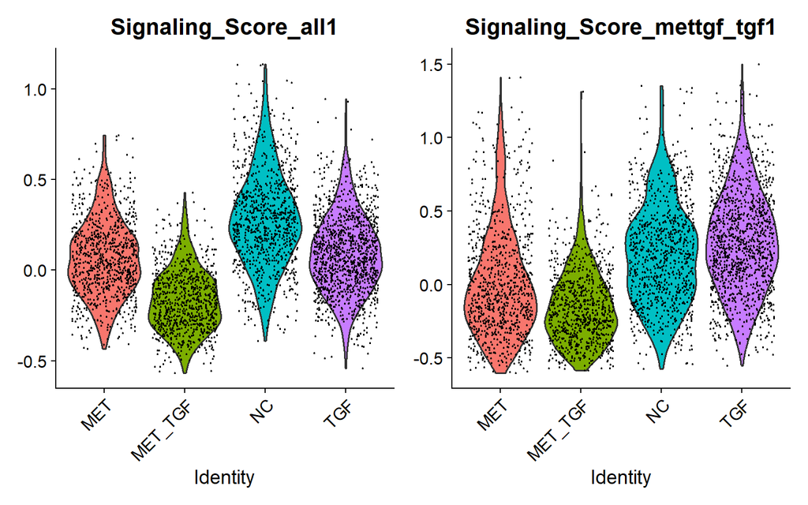

```r
p <- VlnPlot(
  Cardio,
  features = c("Signaling_Score_all1", "Signaling_Score_mettgf_tgf1"),
  group.by = "condition",
  combine = TRUE
)
p
```

```r
ggsave(
  filename = "Signaling_Score_combine1.jpg",
  plot = p,
  width = 8,
  height = 6,
  dpi = 300
)
```

## 4.6 Visualizing Development Scores compare all vs mettgf_tgf

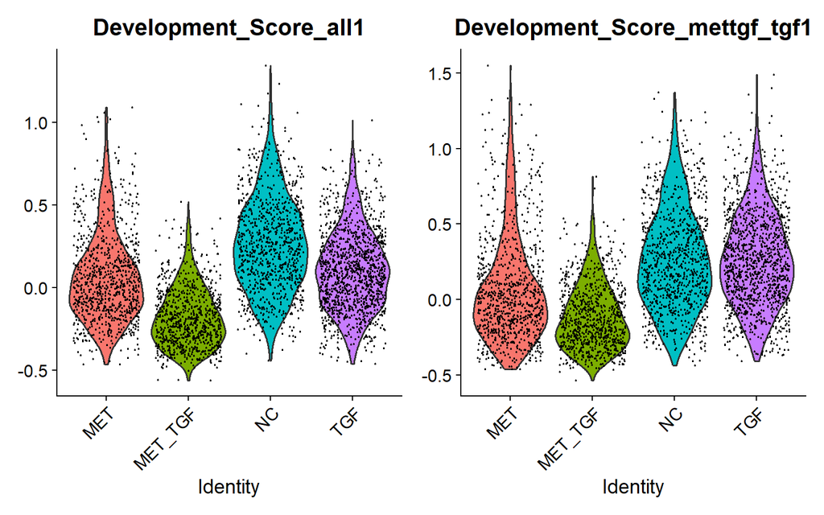

```r
p <- VlnPlot(
  Cardio,
  features = c("Development_Score_all1", "Development_Score_mettgf_tgf1"),
  group.by = "condition",
  combine = TRUE
)
p
```

```r
ggsave(
  filename = "Development_Score_combine1.jpg",
  plot = p,
  width = 8,
  height = 6,
  dpi = 300
)
```

## 4.7 Visualizing Cell Death Scores compare all vs mettgf_tgf

```r
# --- plot 1 ---
if ("Cell_death_Score_all1" %in% colnames(Cardio@meta.data) &&
    !all(is.na(Cardio$Cell_death_Score_all1)) &&
    length(unique(na.omit(Cardio$Cell_death_Score_all1))) > 1) {

  p_all <- VlnPlot(
    Cardio,
    features = "Cell_death_Score_all1",
    group.by = "condition"
  ) + ggtitle("All genes")

} else {

  p_all <- ggplot() +
    annotate("text", x = 0.5, y = 0.5,
             label = "No valid data (NA or no variation)",
             size = 5) +
    theme_void() +
    ggtitle("All genes")
}

# --- plot 2 ---
if ("Cell_death_Score_mettgf_tgf1" %in% colnames(Cardio@meta.data) &&
    !all(is.na(Cardio$Cell_death_Score_mettgf_tgf1)) &&
    length(unique(na.omit(Cardio$Cell_death_Score_mettgf_tgf1))) > 1) {

  p_cond <- VlnPlot(
    Cardio,
    features = "Cell_death_Score_mettgf_tgf1",
    group.by = "condition"
  ) + ggtitle("mettgf_tgf")

} else {

  p_cond <- ggplot() +
    annotate(
      "text",
      x = 0.5, y = 0.5,
      label = "Too few genes (<5)\nor no variation",
      size = 5
    ) +
    theme_void() +
    ggtitle("mettgf_tgf")
}

# --- Combined ---
p_combined <- p_all + p_cond

ggsave(
  filename = "Cell_death_Score_combine1.jpg",
  plot = p_combined,
  width = 12,
  height = 6,
  dpi = 300
)
```